# Money and Education

## Introduction

Education is a key component in public policy. As funds for public schools dwindle due to increasing budget restrictions, the debate revolves around both the share of education’s budget and the most efficient allocation of these funds from the public purse. In the following case, we can see how an immature knowledge of statistics can lead to potentially disastrous public policy results and how a fuller understanding of these problems can best delineate the true story and best affect the lives of people.

In the article “Meaningless Money Factor” (1993), George F. Will, a political essayist for the Washington Post, points to case studies where some states with the lowest expenditure per student had the highest SAT scores and vice versa–the SAT test is a national college entrance examination used to indicate the academic preparation level for American high school students. He notes that this is a general trend and that the evidence shows that there is a negative correlation between teacher salaries and SAT scores. He concludes with his quip: “The fact that the quality of schools… [fails to correlate] with education appropriations will have no effect on the teacher unions’ insistence that money is the crucial variable.”

This evidence is somewhat counterintuitive to the idea that paying school teachers more will result in better grades as a result of improved quality of instruction and teaching talent. However, as we will see, the negative correlation does in fact exist! Does this mean that we should reduce public high school teachers’ salaries in order to best improve the academic futures of their students? In this document, we will examine the relationship between teachers’ salary and academic performance using SAT scores and introduce the idea of confounding variables.

### Data

The data is from the paper “Getting What You Pay For: The Debate Over Equity in Public School Expenditures” by Deborah Lynn Guber (1999) from the Journal of Statistics Education.

There are a number of variables listed in the data description collected from 1994-1995 from public elementary and secondary schools:

State – Name of state  
expend – expenditure per pupil in average daily attendance (in thousands of U.S. dollars) ratio – Average pupil to teacher ratio  
salary– Estimated average annual salary of teachers (in thousands of US dollars)  
frac – Percentage of all eligible students taking the SAT  
verbal – Average verbal SAT score  
math – Average math SAT score  
sat – Average total score on the SAT

## Data Analysis

### Correlation and Causation

Correlation is the relationship between two different variables. When two variables are positively correlated, they have a positive association with each other; that is, when there is more of one variable, there is more of the other. For example, there might be more hot chocolate sales during colder weather and more iced tea sales during hot weather. When two things are negatively correlated with each other, they will have a negative association with each other. For example, when people have more money, they might be less inclined to purchase off-brand goods (such examples are known as inferior goods in economics).

It is important to note that correlation does not equal causation. That is, just because two variables move together well does not mean that one causes the other variable to increase. For example, if an epidemic spreads in certain parts of the world, higher numbers of doctors in those places with high incidences of a disease does not mean that the doctors caused the disease. Rather, doctors might have been sent to those places to address it.

When using an explanatory variable, which is the variable that we consider that might affect the variable of interest (i.e. the independent variable), we need to make sure that the explanatory variable is not really just showing the effect of another variable. Often, explanatory variables will have a number of other variables that are correlated with them, which can skew the explanatory power of the observations.

We see a negative correlation between sat scores and teacher salary:

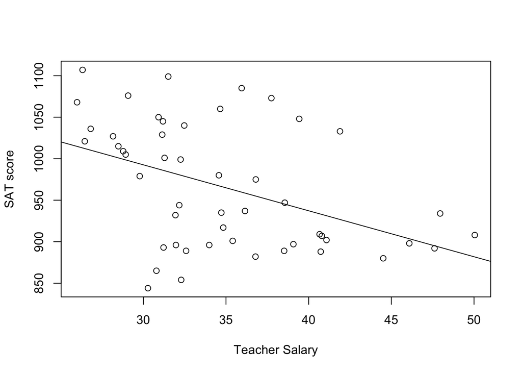

### Confounding Variables

We note that states with the lowest fraction of students taking the SAT generally have the highest average scores. This might be due to selection bias–the students who actually take the SAT in places with low SAT participation rates tend to be prepared. In contrast, if the majority of students are expected to take the SAT in certain states, then students who are average are likely to take the tests. Thus, the average SAT score reflects this variable.

The key to observing the effects of teacher salary on SAT scores without the effects of frac is to hold constant, or control for, the frac variable.

This phenomenon is known as Simpson’s Paradox. This paradox occurs when the trends between two variables become neutral or reverses when other variables are introduced.

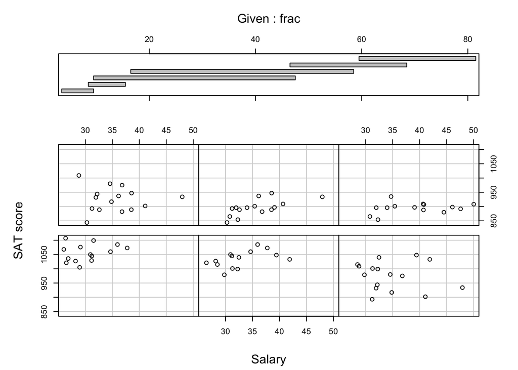

```r
# fixing a confounding variable
coplot(sat ~ salary | frac, data = satDF, xlab = "Salary", ylab = "SAT score")
```

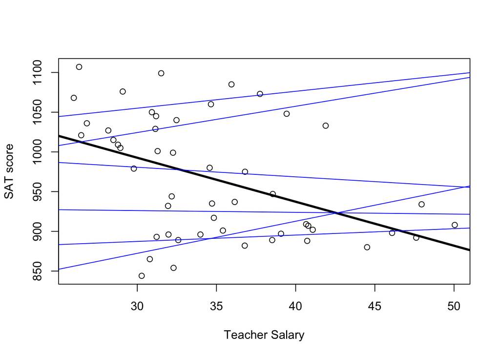

```r
frac_intervals = co.intervals(satDF$frac)
# write a function that extract 6 frac groups
frac_group = function(interval_group, data = satDF$frac){
  which(satDF$frac >= interval_group[1] & satDF$frac <= interval_group[2])
}
frac_list = apply(frac_intervals, 1, frac_group)
lm_list = list()
for(i in 1:6){
lm_list[[i]] = lm(sat[frac_list[[i]]] ~ salary[frac_list[[i]]], data = satDF)
}
lm_summary_list = lapply(lm_list, summary)
## should we be checking individual regression significance?
plot(sat ~ salary, data = satDF, xlab = "Teacher Salary", ylab = "SAT score")
lm.Ex = lm(sat ~ salary, data = satDF)
abline(lm.Ex, lwd = 3)
for(i in 1:6){
  abline(lm_list[[i]], col = "blue")
}
```